# Which dose, and how would we know?

Using simulation and search to choose better early-trial designs

Naim Rashid

Department of Biostatistics · Lineberger Comprehensive Cancer Center · UNC Chapel Hill

tbd-venue · 2026

[figure not shown]

## Overview

Section 1

The problem

Choosing a dose is a search problem in disguise.

Section 2

The method

Search proposes. Verification decides.

Section 3

The evidence

What we learned, and why the dose choice matters later.

Section 1

The problem

Why is choosing one dose harder than it looks?

## A small early trial can determine the dose used in everything that follows

**The setting**  
A few dose levels, a few dozen patients.

**The decision**  
Which one dose is carried into the next trial.

**The catch**  
What happens to one small group determines which dose the next group receives.

## Every patient contributes two facts

Harm

**A side effect, or none**  
Did this patient have a serious toxic reaction in the first cycle?

Benefit

**A response, or none**  
Did this patient’s tumour shrink?

More dose can mean more benefit, and more harm.

## The highest tolerable dose is not always the right dose

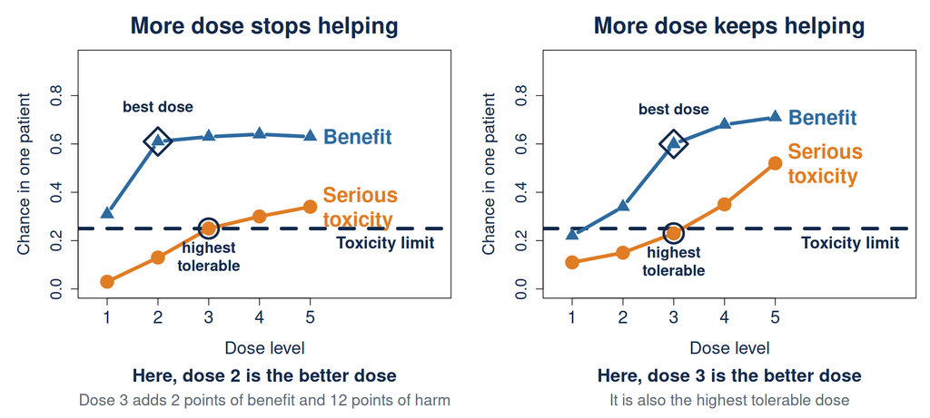

Push to the ceiling and you can buy far more harm than benefit.

## A dose choice fails in two opposite directions

**Too low, lose benefit**  
Nothing looks wrong inside the trial.

**Too high, cause avoidable toxicity**  
The next trial can stop for safety.

Both mistakes can make a promising drug look unsuccessful.

## A trial design is really a bundle of choices

**Settings that get chosen**

when to move up · when to move down · when to abandon a dose · how many patients to enroll

**Usually chosen by convention**

published defaults, reused. Tuning advice that does not say to what.

Change any one and the trial behaves differently.

## A design is acceptable only if it clears all three requirements

**Find the dose**  
Get the right one often enough.

**Stop when you should**  
If no dose is safe, pick none.

**Do not overexpose**  
Rarely treat above the tolerable dose.

Program success is a different quantity.

Only simulation says whether a design meets them.

## Simulation says how one design behaves. It does not say which design to try next.

One design  
↓ thousands of simulated trials  
RIGHT DOSE · SAFE STOPPING · OVEREXPOSURE  
↓  
**But which settings should we try next?**

## The trial that motivated this picked the right dose only about half the time in its own simulations

51.7%

A pancreatic cancer trial at Lineberger

Reasonable choices. Nothing establishes they meet a stated requirement.

LCCC2220-DCT · NCT06483555

## Three design families, three different targets

**Find the highest safe dose**  
Toxicity only

**First find safety, then optimize benefit**  
Toxicity, then benefit

**Balance benefit and harm from the start**  
Benefit against harm throughout

Each is scored on the target it pursues, never on one it never aims at.

## Sometimes we can try every possible design. Sometimes there are infinitely many

**8 possible designs**  
Test all 8. An optimizer here measures nothing.

**Continuous settings**  
There is no list to write down.

First ask whether search is even necessary.

Section 2

The method

How do we decide what to simulate next, and when do we trust the answer?

## This is a familiar computational problem

This is the same problem as tuning a machine-learning model.

**Machine learning**  
hyperparameters  
↓  
expensive training run  
↓  
validation performance

**Dose-finding design**  
design settings  
↓  
expensive simulated trials  
↓  
right dose, safe stopping, overexposure

Same shape as tuning, except all three requirements must be met.

## BATON-D needs a simulator, not a formula

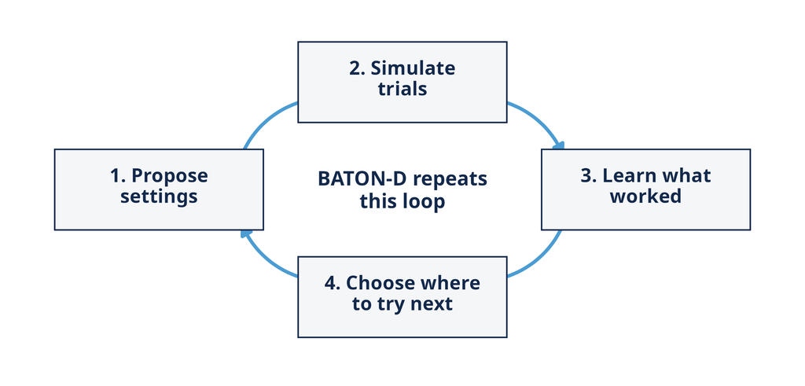

You supply a simulator and the requirements. It returns settings that meet them.

## The model fills in the expensive simulations we have not run

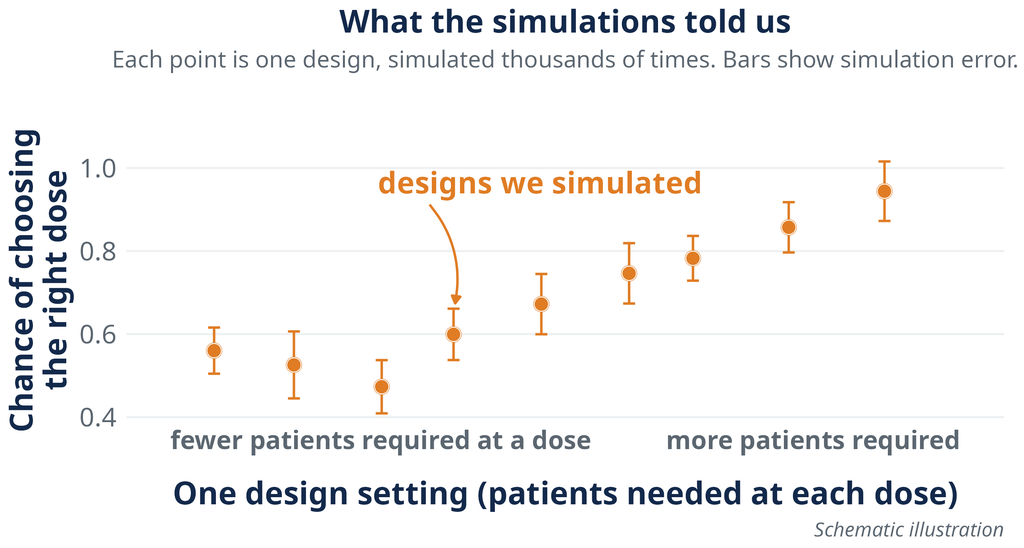

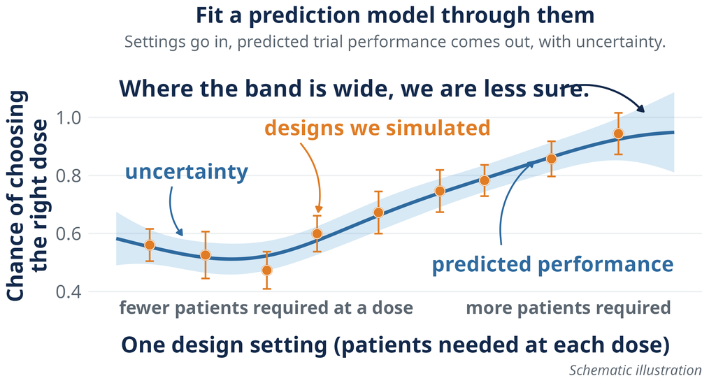

## The next simulation goes where a promising design can most improve

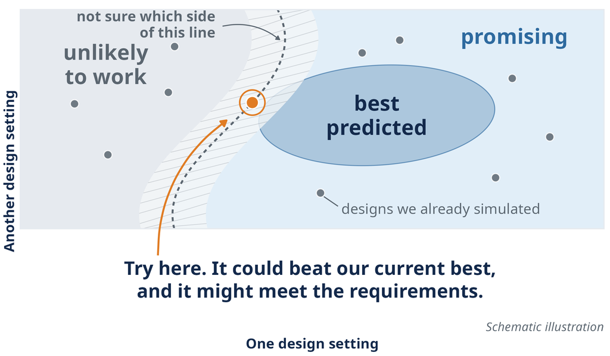

Weigh the possible gain against the chance every requirement holds.

## Search proposes. Verification decides.

**Search**  
find a promising winner  
800 simulated trials each

lock the winner  
→

**Verify**  
test that winner on **fresh simulations**  
4,000 of them, separate randomness

bound each  
requirement  
→

Met, not met,  
or unresolved

The winner of a noisy search looks better than it is, exactly because it won.

## Optimization does not remove human judgment. It forces us to declare it in advance

Situations

Requirements

Settings

Objective

Simulation budget

Every one of them written down, read back, and fixed before anything runs.

Section 3

The evidence

What was established, and what does it cost later?

## Across 60 calibration problems, search nominated 36 and verification established 25

60

calibration problems

→

36

nominated by search

AND THOSE 36 SPLIT INTO

25

verified as meeting all three

+

11

unresolved

+

0

shown to fail

Search is deliberately optimistic. Verification stops us claiming more than the evidence supports.

## Unresolved is not failure, and it is not almost

**Met**  
Enough evidence, yes.

**Unresolved**  
Not enough evidence either way.

**Not met**  
Enough evidence, no. This happened 0 times.

Never settled by falling back to the point estimate.

## A verdict is conditional on the situations chosen in advance

| Which situations the design had to handle | Problems | Established |
| --- | --- | --- |
| From published simulations | 18 | 9 (50%) |
| From the real protocol’s thresholds | 27 | 16 (59%) |
| From a second design’s evaluation | 15 | 0 (0%) |

A design can be declared successful only for the situations we chose to test.

## What a design reaches depends on the settings searched

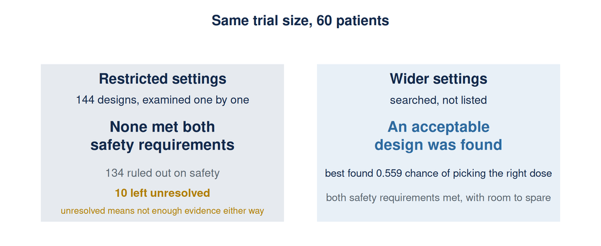

Searching a wider space changed what was reachable. Best found, never a best possible.

## Every guided run that returned a design beat every random run at the same budget

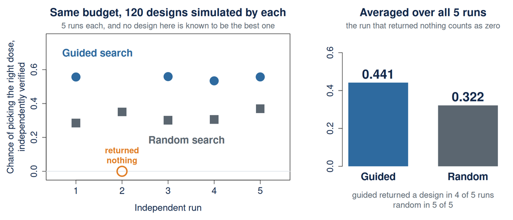

Five runs, no known best design. This is a diagnostic, not a general ranking.

## Where every design could be listed, the search matched the best one

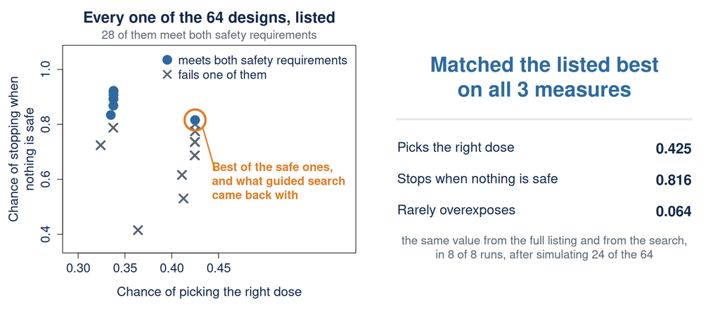

This validates the search where the answer is known. It does not show search was needed.

## A better dose choice does not always buy a better program

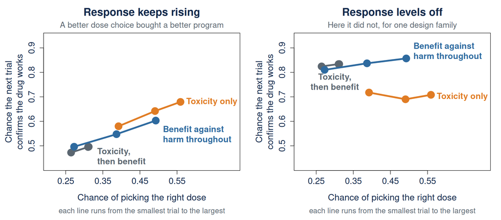

Where response levels off, a sharper dose choice buys almost nothing downstream.

## Meeting the requirements is easy if you spend enough patients

**Spend more**  
Growing the trial from 24 to 96 patients improved correct dose selection by 5 to 22 percentage points.

**It stops paying**  
Where response levels off, those extra patients improved the next trial by at most 5 points.

Not easier requirements. The smallest design that still meets them.

## What a trial team receives

| Requirement | Minimum needed | Estimated result | Conservative bound | Verdict |
| --- | --- | --- | --- | --- |
| Picks the right dose | 0.50 | 0.527 | 0.510 | met |
| Stops when nothing is safe | 0.80 | 0.839 | 0.826 | met |
| Rarely overexposes | 0.10 | 0.073 | 0.082 | met |

Bound, the value we are confident it exceeds, or stays below.

## The two ways a dose choice fails do not fail the same way

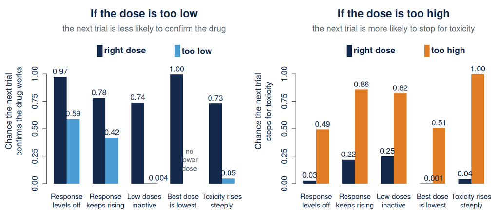

Forwarding low loses benefit quietly. Forwarding high turns the next trial into a safety stop.

## A program can report success and still be on the wrong dose

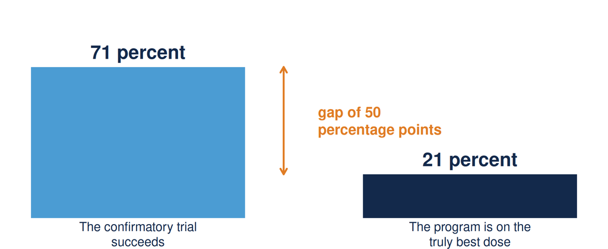

Judged on confirmation alone, this would be recorded as a clear success.

## Optimizing dose selection can choose the wrong design for the whole program

Once confirmation is included.

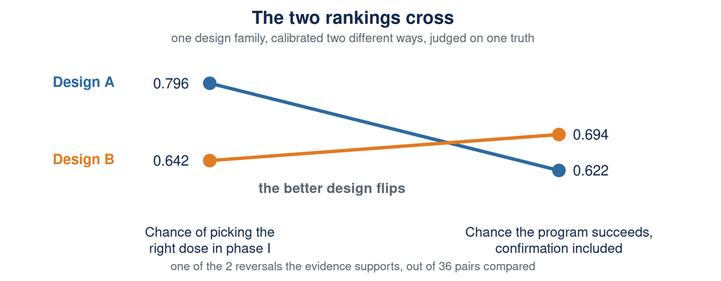

## Not every wrong dose costs the same

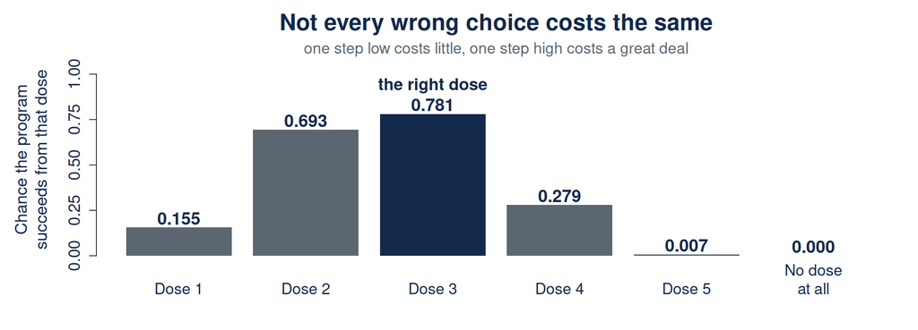

The usual measure scores every wrong dose alike. The program does not.

## What transfers, and what does not

**Transfers**  
Keeping both doses. Carrying the earlier evidence across the boundary.

**Does not**  
Paying for a stage that re-picks one dose, when a plateau leaves the two nearly alike.

A re-picking stage reads response. Where response cannot tell the doses apart, it is a coin flip.

## Carrying both doses through confirmation raises the chance of ending on the right one

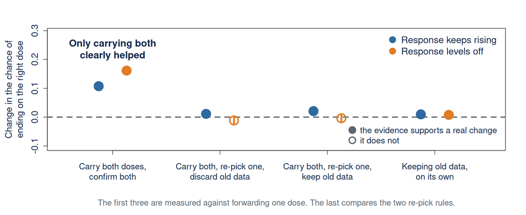

Carrying a second dose is insurance. What it is worth depends on the shape of the response.

## Early decisions become downstream commitments

**Sotorasib**, an approved cancer drug  
**960 mg**, the highest dose tested early  
↓ approved at that dose  
**240 versus 960 mg** compared only after approval  
↓  
**time to worsening was similar at both**

The dose question stayed open until after approval. That dose was not shown wrong.

CodeBreaK 100 · Ann Oncol 2023 · Eur J Cancer 2024

## Each phase transition closes some options

**Choose a dose**

one dose crosses  
→

**Look for a signal**

what is left  
→

**Confirm it**

At each boundary you decide  
**1 which doses survive · 2 which earlier data still count · 3 which questions can still be answered**

Which patients choose a dose, and which patients support the claim about it.

## Where this goes

#### More realistic outcomes

richer endpoints · next

Graded toxicity, ordinal response, late-onset events. The layer does not care what the simulator computes.

#### More possible truths

BATON-C · with Amber Young

Calibrate against a declared family of plausible truths rather than one.

#### Optimize the whole program

long-term

Choose dose, population and boundaries together, as one design.

## What I hope you remember

- Choosing a trial design is a search problem. Simulation alone does not tell you what to try next.
- Verify the chosen design on fresh simulations before making a claim.
- The design most likely to pick the right dose is not always the design most likely to produce a successful program, once confirmation is included.

## Acknowledgments

#### Clinical and trial

- The LCCC2220-DCT investigators and study team
- UNC Lineberger Comprehensive Cancer Center

#### Statistics

- **Amber Young** (UNC), who co-leads the confirmatory-trial calibration work
- Rashid Lab

Thank you

Questions

naim@unc.edu · rashidlab.github.io

Backup

Reference slides

## Backup: the model and the rule that picks the next design

How search works

- A Gaussian process surrogate on the objective and on **each** constraint.
- Candidates scored by **expected improvement multiplied by the modelled probability that every constraint holds**.
- With nothing feasible seen yet there is no incumbent, so the rule minimizes expected constraint violation with an exploration term. The best observed value is never substituted, because an attractive objective can come from violating a constraint.
- **Lattice coordinates are optimized on the lattice**, so every proposal is realizable, and proposals are deduplicated by the induced decision rule rather than by coordinates.

Approximations and limitations

1. Common random numbers correlate the Monte Carlo errors of different candidates, and the surrogate likelihood treats observations as independently noisy.
2. The selection rule multiplies per-constraint feasibility probabilities, and the three constraints are computed from the same simulated trials.
3. Observation noise on each constraint is supplied from the known replicate count rather than inferred from the fit. The trial-size objective carries no replicate-level noise model.

## Backup: the frozen calibration specification

Fixed in advance

- the situations and their truth definitions
- the constraint set, its thresholds and the situation class each is judged over
- how a constraint is aggregated across situations, worst case by default
- the range of settings searched
- the objective and the weights swept, 0.0, 0.5, 1.0
- the replicate counts, 800 at search and 4,000 at verification
- how the bounds are adjusted so that all 3 requirement claims hold at once, at total error 0.05

Thresholds in force

- pick the right dose at least 0.80 (simulation track) or 0.50 (application track)
- stop without selecting at least 0.80 of the time where no dose is acceptable
- treat more than 60 percent of enrolled patients above the tolerable dose at most 0.10 of the time

Disclosures

**Two of them, and neither was discovered afterwards.** The object was derived from the campaign it governs, and that campaign was not registered in advance. Two of its components were not fixed before results existed, and both are named in the paper.

**A post-result alteration creates a new analysis.** It does not revise the verdict the prespecified object supports.

## Backup: the reference trial and its reconstruction

Reference trial

**The protocol** (LCCC2220-DCT, NCT06483555), six dose levels, a toxicity-only first stage on a boundary table, then a stage ranking admissible doses by posterior mean utility over the four toxicity-by-response outcomes.

**Two toxicity thresholds, deliberately different.** Admissibility uses the maximum tolerable rate 0.25. The first stage aims below it, at 0.20, so early exploration sits under the ceiling.

**Published exact best-dose selection, 51.7% and 45.1%**, for its own reference design under its own scenarios. That is a reference point and it bounds nothing about what calibration reaches elsewhere.

Reconstruction limitations

Every decision rule the protocol states was audited against the protocol text, including both boundary tables row by row. **Two quantities are not reproduced.**

1. **Expected first-stage size** in three of four scenarios. It enters no constraint and can move no verdict.
2. **Allocation to doses above those the design opened.** This one does bear on overexposure and is therefore not orthogonal to the safety conclusion.

Verified exposure here spans 0.029 to 0.045 against a 0.10 ceiling, so the second discrepancy would have to more than double the quantity it affects before a verdict moved. The application that produced those numbers is closed and postdates the trial’s design.

## Backup: what BATON-D adds beyond existing calibration approaches

Four differences, and optimization is not one of them

1. **An open constraint set** rather than a single fixed overdose rule, with each constraint declaring its own situation class and aggregation rule.
2. **The maximum trial size is calibrated jointly** with the tuning settings. The closest prior work fixes it at 36 patients.
3. **The target is family-specific** rather than common to every design compared, which is what admits toxicity-only and utility designs into one comparison.
4. **Every reported quantity is re-estimated on independent simulations** with exact bounds before any feasibility statement. Prior calibrations report point estimates without uncertainty bounds, which cannot support a feasibility claim.

Existing approaches

**Cyclic calibration** (Chen and Mozgunov), sequential coordinate updates in place of a full grid, changing growth from multiplicative to additive, with a procedure for reducing the calibration scenario set.

**Common two-stage calibration** (Barnett et al.), several combination designs calibrated on correct selection, then each overdose rule calibrated against a working criterion that at least 85 percent of trials recommend no combination under an overly toxic scenario. That is the closest precedent for the safe-stopping requirement here.

Published defaults and tabulated decision rules for model-assisted designs.

**Cyclic calibration was not run as a numerical arm here**, and no numerical comparison with it is claimed.

## Backup: known limits and failure modes

Search evidence

Search reliability is on slide 26 now, not here, because it is a result. What that slide does not carry is that the two comparisons answer different questions, and that a user meeting an empty result would more plausibly rerun from another seed, fall back to an enumerable subset, or report no recommendation, each of which scores the failure differently.

**5 runs and no known best design is a DIAGNOSTIC.** It is not evidence of general superiority to random search. The enumerable benchmark is the stronger of the two, and it is the one measured against a known best design.

Comparators, the complete inventory

Random search at an identical domain, budget, replicate counts, safety screen, seeds and verification path, with the proposer as the only difference. Exhaustive enumeration where the domain permits, which gives a known best design to measure against. **No hand-tuning arm and no grid-search arm exist in this work**, and cyclic calibration is confronted in related work rather than run.

Reconstruction

One family’s reconstruction carries the weakest evidence of the three, because no independent implementation exists to check it against. It reproduces seven of eight published scenarios with the eighth disclosed, and that limitation is restated wherever its results appear.

Generalizability

Binary toxicity and response, independence, a small frozen scenario set, no nominal categorical settings varied. The generality is a property of the interface and the verification layer, not a demonstrated range.

Implementation

The implementation sweeps a grid of trial sizes and calibrates independently at each, so no information is shared between neighbouring sizes and half the realizable sizes are never examined. Searching the group count directly would double the resolution at no extra cost.

## Backup: the overexposure tolerance

The 0.10 tolerance is a working value, so every verified verdict was re-evaluated at 0.05 and 0.20. The re-evaluation is **exact** for a locked design, because a verified bound does not depend on the threshold it is compared against, and no simulation is rerun.

| Safety tolerance | Cross-family verdicts that moved | Exhaustive designs clearing safety | Exactness |
| --- | --- | --- | --- |
| 0.05 | none | 0 of 10 | exact |
| 0.10, in force | the baseline | 0 of 10 | exact |
| 0.20 | none | 6 of 10 | lower bound |

- **No overall verdict moves in the cross-family analysis**, because every configuration already fails on finding the dose and that requirement does not involve the tolerance.
- **The 0.20 count is a lower bound**, because 134 designs were screened out at the working value and never verified. Tightening carries no such gap, so the zero at 0.05 is exact.

**The constraint carries a second chosen constant**, the patient fraction the probability is evaluated against, and it is the more consequential of the two. Its origin is recorded as unestablished. That is not evidence the value is right. It is why a constraint definition belongs in the frozen specification rather than in its implementation.

## Backup: a wider set of situations

Six further situations were constructed on the trial’s full six-dose set and all 39 locked configurations were re-scored on each at 8,000 simulated trials, **with no re-calibration**. These never enter a feasibility claim and are never averaged with one.

| Added situation | Toxicity only | The two utility families |
| --- | --- | --- |
| Worst-case overexposure against a 0.10 ceiling | up to 0.218, on 10 of 39 locked configurations | within the ceiling |
| Response fails, stops without recommending a dose | at most 0.1% | 15.7% to 63.8% |
| Best dose is the lowest admissible level, finds it | at most 1.6% | 65.1% to 90.5% |

- **Safe stopping was judged on the all-toxic failure mode**, and it does not transfer to a response failure mode for a design that never observes response. Every overexposure exceedance above is from the toxicity-only family.
- Re-calibrating on the widened grid, and again with the hardest added situation removed by a rule fixed in advance, **left the coarse-domain conclusion unchanged**, so it is not an artefact of three situations and does not hinge on the single hardest one.

## Backup: dependence between the two endpoints

The association structure is a **Gumbel bivariate binary model**. The marginals are preserved exactly at every value of its parameter, so the true best dose a situation defines does not move as the parameter is swept, and zero is exactly independence.

what any pair of yes-or-no endpoints with these marginals could attain

-0.94

1.00

in blue, everything the sweep covered, independence out to ±0.106

orange tick, this dependence model's own limit at 0.229

**This checks only modest dependence. It does not establish robustness to endpoint association in general.** This family does not span attainable dependence, and stronger dependence needs a different model rather than a wider grid of this one.